# Lab 6: Functions

Functions are critical to an efficient and readable workflow. Although Python and its external packages have a wide variety of functions, you will often times need to create your own for a specific use case. We will build those skills during this lab.

Please complete this lab by providing answers in cells after the question. Use **Code** cells to write and run any code you need to answer the question and **Markdown** cells to write out answers in words. After you are finished with the assignment, remember to download it as an **.html file** and submit it in **ELMS**.

```python
import numpy as np
from datascience import *

# These lines set up graphing capabilities.
import matplotlib
%matplotlib inline
import matplotlib.pyplot as plt

# This is just to make the plots look a certain way
plt.style.use('fivethirtyeight')
```

## Defining functions

Let's write a very simple function that converts a proportion to a percentage by multiplying it by 100. For example, the value of `to_percentage(.5)` should be the number 50 (no percent sign).

A function definition has a few parts.

### `def`

It always starts with `def` (short for **def**ine):

```
def
```

### Name

Next comes the name of the function. Like other names we've defined, it can't start with a number or contain spaces. Let's call our function `to_percentage`:

```
def to_percentage
```

### Signature

Next comes something called the *signature* of the function. This tells Python how many arguments your function should have and what names you'll use to refer to those arguments in the function's code. A function can have any number of arguments (including 0!).

`to_percentage` should take one argument, and we'll call that argument `proportion` since it should be a proportion.

```
def to_percentage(proportion)
```

If we want our function to take more than one argument, we add a comma between each argument name.

We put a colon after the signature to tell Python it's over. If you're getting a syntax error after defining a function, check to make sure you remembered the colon!

```
def to_percentage(proportion):
```

### Documentation

Functions can do complicated things, so you should write an explanation of what your function does. For small functions, this is less important, but it's a good habit to learn from the start. (You should also be heavily commenting within functions you develop. Remember: Transparency is KEY to Open Science.)

In this class, we will follow a particular structure when creating documentation for our functions. You should put whether there are any libraries (dependencies) to run the function and whether there are default arguments/what they mean. Conventionally, Python functions are documented by writing an **indented** triple-quoted string:

```
def to_percentage(proportion):
    """
    Converts a proportion to a percentage.
    Required libraries: None
    Default arguments: None
    """
```

### Body

Now we start writing code that runs when the function is called. This is called the *body* of the function and every line **must be indented with a tab**. Any lines that are *not* indented and left-aligned with the def statement is considered outside the function.

Some notes about the body of the function:

- We can write any code that we would write anywhere else.
- We use the arguments defined in the function signature. We can do this because we assume that when we call the function, values are already assigned to those arguments.
- We generally avoid referencing variables defined *outside* the function.

Now, let's give a name to the number we multiply a proportion by to get a percentage:

```
def to_percentage(proportion):
    """
    Converts a proportion to a percentage.
    Required libraries: None
    Default arguments: None
    """
    factor = 100
```

### `return`

The special instruction `return` is part of the function's body and tells Python to make the value of the function call equal to whatever comes right after `return`. We want the value of `to_percentage(.5)` to be the proportion .5 times the factor 100, so we write:

```
def to_percentage(proportion):
    """
    Converts a proportion to a percentage.
    Required libraries: None
    Default arguments: None
    """
    factor = 100
    return proportion * factor
```

`return` only makes sense in the context of a function, and **can never be used outside of a function**. `return` is always the last line of the function because Python stops executing the body of a function once it hits a `return` statement.

*Note:* `return` inside a function tells Python what value the function evaluates to. However, there are other functions, like `print()`, that have no `return` value. For example, `print()` simply prints a certain value out to the console.

`return` and `print` are **very** different.

**Question 1.Define `to_percentage` in the cell below. Call your function to convert the proportion .2 to a percentage. Name that percentage `twenty_percent`.**

```python
def to_percentage(proportion):
    """
    Converts a proportion to a percentage.
    Required libraries: None
    Default arguments: None
    """
    factor = 100
    return proportion * factor

twenty_percent = to_percentage(.2)
twenty_percent
```

```
20.0
```

Like built-in functions you've used in previous labs (e.g., `max()`, `abs()`), you can use named values as arguments to your function.

**Question 2. Use `to_percentage()` again to convert the proportion named `a_proportion` (defined below) to a percentage called `a_percentage`.**

*Note:* You don't need to define `to_percentage()` again! Like other named values, functions stick around after you define them.

```python
a_proportion = 2**(.5) / 2

print(to_percentage(a_proportion))
```

```
70.71067811865476
```

Here's something important about functions: the names assigned *within* a function body are only accessible within the function body. Once the function has returned, those names are gone. So even though you defined `factor = 100` inside the body of the `to_percentage` function up above and then called `to_percentage`, you cannot refer to `factor` anywhere except inside the body of `to_percentage`:

```python
# You should see an error when you run this. (If you don't, you might have defined factor somewhere above.)
factor
```

```
---------------------------------------------------------------------------
NameError                                 Traceback (most recent call last)
Cell In[4], line 2
      1 # You should see an error when you run this. (If you don't, you might have defined factor somewhere above.)
----> 2 factor

NameError: name 'factor' is not defined
```

**Question 3. Add an argument to `to_percentage()` called "start_percent" and set the default value to zero. If start_percent is equal to 1, make the function convert the input to a proportion (i.e., divide by 100). Test this with the twenty_percent object you created above.**

```python
def to_percentage(proportion, start_percent=0):
    """
    Converts a proportion to a percentage or a percentage to a proportion
    Required libraries: None
    Default arguments: None
    """
    factor = 100

    if start_percent == 1:
        return proportion / factor
    else:
        return proportion * factor

percent_change = to_percentage(twenty_percent, start_percent=1)
percent_change
```

```
0.2
```

As we've seen with built-in functions, functions can also take strings (or arrays, or tables) as arguments, and they can return those things, too.

**Question 4. Define a function called `disemvowel`. It should take a single string as its argument. (You can call that argument whatever you want.) It should return a copy of that string, but with all the characters that are vowels removed. (In English, the vowels are the characters "a", "e", "i", "o", and "u".)**

*Hint:* To remove all the "a"s from a string, you can use `<that_string>.replace("a", "")`. The `.replace()` method for strings returns a new string, so you can call `.replace()` multiple times, one after the other.

```python
def disemvowel(a_string):
    """
    Removes vowels from a string
    """
    return a_string.replace("a", "").replace("e", "").replace("i", "").replace("o", "").replace("u", "")

# An example call to your function. (It's often helpful to run an example call from time to time while you're writing a function, to see how it currently works.)
replace_vowel = "Can you read this without vowels?"
disemvowel(replace_vowel)
```

```
'Cn y rd ths wtht vwls?'
```

### Calls on calls on calls

Just as you write a series of lines to build up a complex computation, it's useful to define a series of small functions that build on each other. Since you can write any code inside a function's body, you can call other functions you've written.

If a function is a like a recipe, defining a function in terms of other functions is like having a recipe for cake telling you to follow another recipe to make the frosting, and another to make the jam filling. This makes the cake recipe shorter and clearer, and it avoids having a bunch of duplicated recipes. It's a foundation of productive programming.

For example, suppose you want to count the number of characters *that aren't vowels* in a piece of text. One way to do that is this to remove all the vowels and count the size of the remaining string.

**Question 5. Write a function called `num_non_vowels`. It should take a string as its argument and return a number. That number should be the number of characters in the argument string that aren't vowels.**

*Hint:* The function `len()` takes a string as its argument and returns the number of characters in it.

```python
def num_non_vowels(a_string):
    """
    The number of characters in a string, minus the vowels.
    Required libraries: None
    Default arugments: None
    """
    return len(disemvowel(a_string))

new_disvowel = "Take these vowels"
# Try calling your function yourself to make sure the output is what you expect.
print(disemvowel(new_disvowel))
print(num_non_vowels(new_disvowel))
```

```
Tk ths vwls
11
```

Functions can also encapsulate code that *does an action* rather than computing a value. For example, if you call `print()` inside a function, and then call that function, something will get printed.

The `movies_by_year` dataset in the textbook has information about movie sales in recent years. Suppose you'd like to display the year with the 5th-highest total gross movie sales, printed in a human-readable way. You might do this:

```python
movies_by_year = Table.read_table("movies_by_year.csv")
rank = 5
fifth_from_top_movie_year = movies_by_year.sort("Total Gross", descending=True).column("Year").item(rank-1)
print("Year number", rank, "for total gross movie sales was:", fifth_from_top_movie_year)
```

```
Year number 5 for total gross movie sales was: 2010
```

After writing this, you realize you also wanted to print out the 2nd and 3rd-highest years. Instead of copying your code, you decide to put it in a function. Since the rank varies, you make that an argument to your function.

**Question 6. Write a function called `print_kth_top_movie_year`. It should take a single argument, the rank of the year (like 2, 3, or 5 in the above examples). It should print out a message like the one above.**

*Note:* Your function shouldn't have a `return` statement.

```python
def print_kth_top_movie_year(k):
    """
    Takes movie year and finds total gross movie sales for top movie
    """
    movies_by_year = Table.read_table("movies_by_year.csv")
    top_movie_by_yr = movies_by_year.sort("Total Gross", descending=True).column("Year").item(k-1)
    whats_that_year = print("Year number", k, "for total gross movie sales was:", top_movie_by_yr)
    return whats_that_year

# Example calls to your function:
print_kth_top_movie_year(2)
print_kth_top_movie_year(3)
```

```
Year number 2 for total gross movie sales was: 2013
Year number 3 for total gross movie sales was: 2012
```

### `print` is not the same as `return`

The `print_kth_top_movie_year(k)` function prints the total gross movie sales for the year that was provided! However, since we did not return any value in this function, we can not use it after we call it. Let's look at an example of another function that prints a value but does not return it.

```python
def print_number_five():
    print(5)
```

```python
print_number_five()
```

```
5
```

However, if we try to use the output of `print_number_five()`, we see that we get an error when we try to add the number 5 to it!

```python
print_number_five_output = print_number_five()
print_number_five_output + 5
```

```
5
```

```
---------------------------------------------------------------------------
TypeError                                 Traceback (most recent call last)
Cell In[53], line 2
      1 print_number_five_output = print_number_five()
----> 2 print_number_five_output + 5

TypeError: unsupported operand type(s) for +: 'NoneType' and 'int'
```

It may seem that `print_number_five()` is returning a value, 5. In reality, it just displays the number 5 to you without giving you the actual value! If your function prints out a value without returning it and you try to use that value, you will run into errors, so be careful!

## Practice Writing Functions

In this question, we'll look at the 2015 compensation of CEOs at the 100 largest companies in California. The data was compiled from a [Los Angeles Times analysis](http://spreadsheets.latimes.com/california-ceo-compensation/), and ultimately came from [filings](https://www.sec.gov/answers/proxyhtf.htm) mandated by the SEC from all publicly-traded companies. Two companies have two CEOs, so there are 102 CEOs in the dataset.

We've copied the raw data from the LA Times page into a file called `raw_compensation.csv`. (The page notes that all dollar amounts are in **millions of dollars**.)

```python
raw_compensation = Table.read_table('raw_compensation.csv')
raw_compensation.show(5)
```

| Rank | Name | Company (Headquarters) | Total Pay | % Change | Cash Pay | Equity Pay | Other Pay | Ratio of CEO pay to average industry worker pay |
| --- | --- | --- | --- | --- | --- | --- | --- | --- |
| 1 | Mark V. Hurd* | Oracle (Redwood City) | $53.25 | (No previous year) | $0.95 | $52.27 | $0.02 | 362 |
| 2 | Safra A. Catz* | Oracle (Redwood City) | $53.24 | (No previous year) | $0.95 | $52.27 | $0.02 | 362 |
| 3 | Robert A. Iger | Walt Disney (Burbank) | $44.91 | -3% | $24.89 | $17.28 | $2.74 | 477 |
| 4 | Marissa A. Mayer | Yahoo! (Sunnyvale) | $35.98 | -15% | $1.00 | $34.43 | $0.55 | 342 |
| 5 | Marc Benioff | salesforce.com (San Francisco) | $33.36 | -16% | $4.65 | $27.26 | $1.45 | 338 |

... (97 rows omitted)

We want to compute the average of the CEOs' pay. Try running the cell below.

```python
np.average(raw_compensation.column("Total Pay"))
```

[output not shown]

You should see an error. Let's examine why this error occurred by looking at the values in the `Total Pay` column.

```python
raw_compensation.column("Total Pay").item(0)
```

```
'$53.25 '
```

```python
type(raw_compensation.column("Total Pay").item(0))
```

```
str
```

It looks like the values in the `Total Pay` column are strings. It doesn't make sense to take the average of string values, so we need to convert them to numbers if we want to do this. Let's extract the first value in `Total Pay`. It's Mark Hurd's pay in 2015, in *millions* of dollars.

```python
mark_hurd_pay_string = raw_compensation.column("Total Pay").item(0)
mark_hurd_pay_string
```

```
'$53.25 '
```

**Question 7. Convert `mark_hurd_pay_string` to a number of *dollars* and call it `mark_hurd_pay`.**

Some hints, as this question requires multiple steps:

- The string method `.strip()` will be useful for removing the dollar sign; it removes a specified character from the start or end of a string. For example, the value of `"100%".strip("%")` is the string `"100"`.
- You'll also need the function `float()`, which converts a string that looks like a number to an actual number.
- Finally, remember that the answer should be in dollars, not millions of dollars.

```python
mark_hurd_pay = float(mark_hurd_pay_string.strip('$')) * 1000000
mark_hurd_pay
```

```
53250000.0
```

To compute the average pay, we need to do this for every CEO. But that looks like it would involve copying this code 102 times.

This is where functions come in. First, we'll define a new function, giving a name to the expression that converts "total pay" strings to numeric values. In the next section, we'll see the payoff: we can call that function on every pay string in the dataset at once.

**Question 8. Copy the expression you used to compute `mark_hurd_pay`, and use it as the return expression of the function below. But make sure you replace the specific `mark_hurd_pay_string` with the generic `pay_string` name specified in the first line in the `def` statement.**

*Hint*: When dealing with functions, you should generally not be referencing any variable outside of the function. Usually, you want to be working with the arguments that are passed into it, such as `pay_string` for this function. If you're using `mark_hurd_pay_string` within your function, you're referencing an outside variable!

```python
def convert_pay_string_to_number(pay_string):
    """
    Converts a pay string like '$100' (in millions) to a number of dollars.
    Required libraries: None
    Default arguments: None
    """
    return float(pay_string.strip('$')) * 1000000
```

## `apply`ing functions

Defining a function is a lot like giving a name to a value with `=`. In fact, a function is a value just like the number 1 or the text "the"!

For example, we can make a new name for the built-in function `max()` if we want:

```python
our_name_for_max = max
our_name_for_max(2, 6)
```

```
6
```

The old name for `max()` is still around:

```python
max(2, 6)
```

```
6
```

Try just writing `max` or `our_name_for_max` (or the name of any other function) in a cell, and run that cell. Python will print out a (very brief) description of the function.

```python
max
```

```
<function max>
```

Why is this useful? Since functions are just values, it's possible to pass them as arguments to other functions. This means we can use tools like the table method `.apply()`. `.apply()` calls a function many times, once on *each* element in a column of a table. It produces an *array* of the results.

Here we use `.apply()` to convert every CEO's pay to a number, using the function you defined:

```python
raw_compensation.apply(convert_pay_string_to_number, "Total Pay")
```

[output not shown]

Here's an illustration of what that did:

[figure not shown]

Note that we didn't write something like `convert_pay_string_to_number()` or `convert_pay_string_to_number("Total Pay ($)")`. The job of `.apply()` is to call the function we give it, so instead of calling `convert_pay_string_to_number` ourselves, we just write its name as an argument to `.apply()`.

**Question 9. Using `.apply()`, make a table that's a copy of `raw_compensation` with one additional column called `Total Pay ($)`. That column should contain the result of applying `convert_pay_string_to_number` to the `Total Pay` column (as we did above). Call the new table `compensation`.**

```python
compensation = raw_compensation.with_column(
    "Total Pay ($)", raw_compensation.apply(convert_pay_string_to_number, "Total Pay"))



compensation
```

| Rank | Name | Company (Headquarters) | Total Pay | % Change | Cash Pay | Equity Pay | Other Pay | Ratio of CEO pay to average industry worker pay | Total Pay ($) |
| --- | --- | --- | --- | --- | --- | --- | --- | --- | --- |
| 1 | Mark V. Hurd* | Oracle (Redwood City) | $53.25 | (No previous year) | $0.95 | $52.27 | $0.02 | 362 | 5.325e+07 |
| 2 | Safra A. Catz* | Oracle (Redwood City) | $53.24 | (No previous year) | $0.95 | $52.27 | $0.02 | 362 | 5.324e+07 |
| 3 | Robert A. Iger | Walt Disney (Burbank) | $44.91 | -3% | $24.89 | $17.28 | $2.74 | 477 | 4.491e+07 |
| 4 | Marissa A. Mayer | Yahoo! (Sunnyvale) | $35.98 | -15% | $1.00 | $34.43 | $0.55 | 342 | 3.598e+07 |
| 5 | Marc Benioff | salesforce.com (San Francisco) | $33.36 | -16% | $4.65 | $27.26 | $1.45 | 338 | 3.336e+07 |
| 6 | John H. Hammergren | McKesson (San Francisco) | $24.84 | -4% | $12.10 | $12.37 | $0.37 | 222 | 2.484e+07 |
| 7 | John S. Watson | Chevron (San Ramon) | $22.04 | -15% | $4.31 | $14.68 | $3.05 | 183 | 2.204e+07 |
| 8 | Jeffrey Weiner | LinkedIn (Mountain View) | $19.86 | 27% | $2.47 | $17.26 | $0.13 | 182 | 1.986e+07 |
| 9 | John T. Chambers** | Cisco Systems (San Jose) | $19.62 | 19% | $5.10 | $14.51 | $0.01 | 170 | 1.962e+07 |
| 10 | John G. Stumpf | Wells Fargo (San Francisco) | $19.32 | -10% | $6.80 | $12.50 | $0.02 | 256 | 1.932e+07 |

... (92 rows omitted)

Now that we have all the pays as numbers, we can learn more about them through computation.

**Question 10. Compute the mean total pay of the CEOs in the dataset.**

```python
average_total_pay = compensation.column("Total Pay ($)").mean()
average_total_pay
```

```
11445294.117647059
```

**Question 11. Companies pay executives in a variety of ways: in cash, by granting stock or other equity in the company, or with ancillary benefits (like private jets). Compute the proportion of each CEO's pay that was cash. (Your answer should be an array of numbers, one for each CEO in the dataset.)**

*Note:* When you answer this question, you'll encounter a red box appearing below your code cell that says something like `RuntimeWarning: invalid value encountered in true_divide`. Don't worry too much about the message. Warnings are raised by Python when it encounters an unusual condition in your code, but the condition is not severe enough to warrant throwing an error.

The warning below is Python's cryptic way of telling you that you're dividng a number by zero. If you extract the values in `Total Pay ($)` as an array, you'll see that the last element is 0.

```python
# You might have some intermediate steps here.
cash_proportion = raw_compensation.apply(convert_pay_string_to_number, "Cash Pay") / compensation.column("Total Pay ($)")
cash_proportion
```

```
/tmp/ipykernel_26805/3954858940.py:2: RuntimeWarning: invalid value encountered in divide
  cash_proportion = raw_compensation.apply(convert_pay_string_to_number, "Cash Pay") / compensation.column("Total Pay ($)")
```

```
array([ 0.01784038,  0.01784373,  0.55421955,  0.02779322,  0.13938849,
        0.48711755,  0.19555354,  0.12437059,  0.25993884,  0.35196687,
        0.3075693 ,  0.22138635,  0.13126362,  0.1708126 ,  0.23099415,
        0.06734817,  0.13043478,  0.28004957,  0.33229814,  0.15355805,
        0.29337748,  0.21829105,  0.31100478,  0.25086147,  0.2299169 ,
        0.16991643,  0.31795947,  0.26188786,  0.28357143,  0.15654718,
        0.38168558,  0.28934426,  0.20361248,  0.47650453,  0.45643154,
        0.36402027,  0.2177626 ,  0.24763543,  0.42562724,  0.2610261 ,
        0.18361836,  0.1444548 ,  0.33333333,  0.10834132,  0.20925747,
        0.97276265,  0.22979552,  0.22789784,  0.37893701,  0.25175527,
        0.73895582,  0.37018256,  0.2412731 ,  0.2133758 ,  0.20553781,
        0.23318872,  0.33664459,  0.3875969 ,  0.56094808,  0.11757991,
        0.35239207,  0.24463007,  0.25      ,  0.23712575,  0.43377886,
        0.31424936,  0.46363636,  0.32585752,  0.24766977,  0.98755187,
        0.27184466,  0.96207865,  0.31831395,  0.81979321,  0.23795181,
        0.17530488,  0.21172638,  0.37162162,  0.27288136,  0.26994907,
        0.55148342,  0.3597786 ,  0.        ,  0.47154472,  0.47154472,
        0.29753915,  0.16235294,  0.48529412,  0.46819338,  0.32526882,
        0.98958333,  0.61130742,  0.67021277,  0.75510204,  0.50837989,
        0.98809524,  0.98039216,  0.9893617 ,  0.87654321,  0.        ,
        1.        ,         nan])
```

### Calculating Previous Year's Pay

Check out the `% Change` column in `compensation`. It shows the percentage increase in the CEO's pay from the previous year. For CEOs with no previous year on record, it instead says "(No previous year)". The values in this column are *strings*, not numbers, so like the `Total Pay` column, it's not usable without a bit of extra work.

**Question 12. Create a new table called `with_previous_compensation`. It should be a copy of `compensation`, but with the "(No previous year)" CEOs filtered out, and with an extra column called `2014 Total Pay ($)`. That column should have each CEO's pay in 2014.**

*Hint 1:* You can print out your results after each step to make sure you're on the right track. Split the cell to make this easier to do!

*Hint 2:* I've provided a structure that you can use to get to the answer. However, if it's confusing, feel free to delete the current structure and approach the problem your own way!

```python
# Definition to turn percent to number
def percent_string_to_num(percent_string):
    """
    Converts a percentage string to a number.
    Required libraries:
    Default arguments:
    """
    return float(percent_string.split("$"))

# Compensation table where there is a previous year
# having_previous_year should be a Table
drop_no_previous_year = compensation.where("% Change", are.not_equal_to("(No previous year)")


# Get the percent changes as numbers instead of strings
# We're still working off the table having_previous_year
# percent_changes should be an array
percent_changes = drop_having_previous_year.apply(percent_string_to_num, "% Change"))


# Calculate the previous year's pay using having_previous_year and percent_changes
# previous_pay should be an array
previous_pay = drop_no_previous_year * percent_changes

# Put the previous pay column into the having_previous_year table
# with_previous_compensation should be a Table
with_previous_compensation = compensation.with_column(
    "% Changes", raw_compensation.apply(convert_pay_string_to_number, "% Changes"))

with_previous_compensation
```

```
  Cell In[242], line 18
    percent_changes = drop_having_previous_year.apply(percent_string_to_num, "% Change"))
    ^
SyntaxError: invalid syntax
```

**Question 13. What was the mean pay of these CEOs in 2014?**

```python
average_pay_2014 = compensation.column("Total Pay ($)").mean()
average_pay_2014
```

```
11445294.117647059
```

**Question 14. Make a histogram of the total pay of the CEOs in `compensation`.**

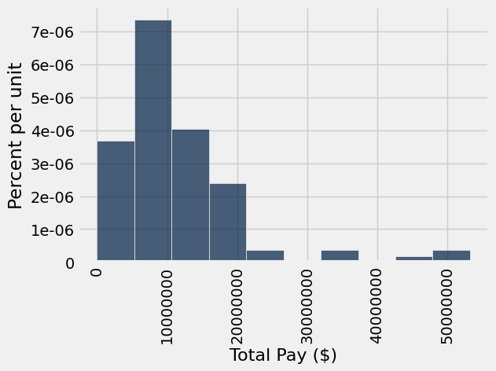

```python
compensation.hist("Total Pay ($)")
```

**Question 15. How many CEOs made more than $30 million in total pay?**

*Hint:* Use the table method `.where()` and the property `num_rows`.

```python
compensation.where("Total Pay ($)", are.above_or_equal_to(30)).num_rows
```

```
101
```

That's all for now. Please let us know if you have trouble understanding anything covered in this module, as we will only continue to build on this material in the coming weeks.